# Modelling Peak Electricity Demand in Great Britain

15, Jinhua Li s2761681, Shaoxuan Quan s2765780, Jiawu Wang s2282849

Word count：2974

# 1 Introduction

## 1.1 The introduction of the task

NESO (National Electricity System Operator) manages and plans the electricity system in Great Britain, requiring long-term peak demand forecasts to avoid over- or under-building infrastructure. Our goal is to develop a practical linear regression model using historical data to predict daily future peak electricity demand.

## 1.2 The Introduction of the Used Datasets

This study utilizes two datasets:

1. Dataset “SCS_demand modelling.csv” (3,479 daily observations): This dataset contains electricity demand data from 1991 to 2013, recorded at 6 PM from November to March each year. It also includes data on wind and solar, along with various temperature- and time-related indicators.
2. Dataset “SCS_hourly_temp.csv” (219,144 hourly observations)：This dataset contains hourly temperature data from 1st of January, 1991, at 00:00 to 31th of December, 2015, at 23:00.

## 1.3 The Outline of Modeling

### 1.3.1 Overall Approach to Modeling Future Daily Peak Electricity Demand

We developed our Multiple Linear Regression model through iterative refinement, starting from a baseline model $M_0$. By addressing its shortcomings with feature engineering, variable selection, and data preprocessing, we arrived at the final model. All parameters were estimated using the least squares method.

Our goal was to build a linear regression model to predict peak electricity demand. We began with a preliminary data analysis, converting **wdayindex**, **monthindex**, **start_year**, and **DSN** from numerical to categorical variables. The baseline model $M_0$, tested on the preprocessed data, showed poor performance (e.g., low $R^2$). After identifying data issues, we revised variable selection to improve model effectiveness. We replaced temp with **TE**, added **start_year** and **DSN**, and modified **solar_S**. Incorporating domain knowledge, we adjusted **TE** to form Model $M_1$, then introduced interaction and higher-order terms to develop Model $M_2$.

To evaluate model performance,we use **Adjusted $R^2$**, **MSE** and **BIC** as criteria to evaluate the model’s goodness of fit. We conducted **K-fold** cross-validation for all models and compared their validation results and use **Bootstrap** to test the model’s stability. A comprehensive assessment indicated that Model $M_1$ achieved the best overall performance.

### 1.3.2 Key Conclusions from the Analysis

We consider Model $M_1$ to be the optimal linear regression model, achieving an $R^2$ of 0.9578 and an adjusted $R^2$ of 0.9555. The data processing and application steps are relatively straightforward, and the model maintains strong interpretability. Given its practical advantages, Model $M_1$ can provide valuable support for NESO’s future forecasting efforts.

Based on the model results, solar conditions and temperature significantly impact peak demand prediction. NESO should prioritize monitoring and improving the accuracy of these variables. Increased solar capacity will raise peak electricity demand, while higher temperatures will reduce it. Additionally, as electricity demand is influenced by many external factors, our linear regression model remains flexible for future enhancements, including adding new predictive variables.

# 2 Data description and exploratory analysis

## 2.1 Analysis of Key Data Features and Visualizations

The dataset `SCS_demand modelling` contains twelve variables. Since the given assupmtion said that daily peak demand occurs at **6p.m.**, all of data in this dataset are about the peak demand and other conditions when peak demand happens. They are **Date**, **wind**, **solar_S**, **demand_gross**, **temp**, **wdayindex**, **monthindex**, **year**, **TO**, **TE**, **start_year** and **DSN**.

Among them, the variable **demand_gross**(MW) will serve as our fitting target, and we aim to model it to estimate its values, which represents the end-user consumption minus embedded generation of electricity demand for **6p.m.** on the given date.

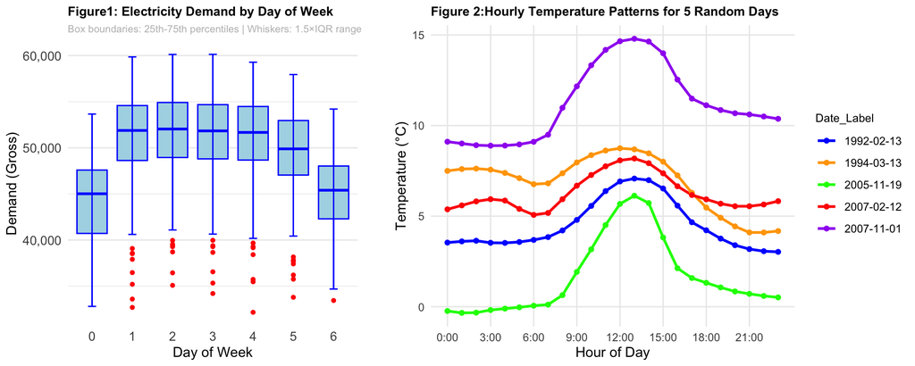

Variables **wind**, **solar_S**, **temp**, **TO**, **TE** are the main weather factors in the model. We use them to investigate the effect the weather to the electricity demand. Variables **wind** and **solar_S** represent the estimated capacity factor of wind and solar generation respectively at **6 PM** on the given date. Variable **temp** represents British population-weighted average temperature. Variable **TO** is the average temperature from **3 PM** to **6 PM** on given date and variable **TE** is the average of **TO** at **6 PM** and **TE** at **6 PM** on the previous day.

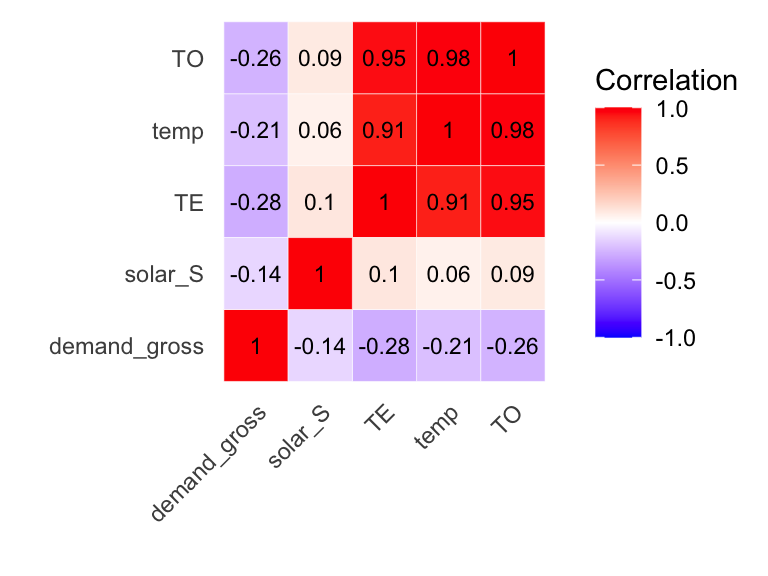

Figure 3: Correlation Heatmap of Demand Predictors

**wdayindex**, **monthindex**, **year**, **start_year**, and **DSN** are key temporal variables. **wdayindex** (0 = Sunday) indicates the day of the week, **monthindex** (0 = January) the month, **start_year** the winter period’s starting year, and **DSN** the days since November 1st.

Among these five time-related variables, **wdayindex**, **monthindex**, and year are inherently categorical, indicating specific days, months, and years, making them independent. In contrast, **start_year** and **DSN** are interrelated and exhibit temporal dependencies.

Besides, since each cycle of **DSN** (starting on November 1st and ending on March 31st of the following year) fully encompasses each cycle of **monthindex** (which follows the same period) while providing a more granular representation, we will use **DSN** data exclusively in the subsequent analysis. Apart from the initially given model, **monthindex** data will no longer be used. Furthermore, based on the chi-square test: `chisq.test(table(data1$monthindex,data1$DSN))`:

```
##
##  Pearson's Chi-squared test
##
## data:  table(data1$monthindex, data1$DSN)
## X-squared = 13871, df = 604, p-value < 2.2e-16
```

Since the p-value is less than $2.2e-16$, we can more rigorously confirm the strong correlation between the two datasets.

Additionally, we randomly selected 20 data points from dsn 1 to 152 and plotted a boxplot of their corresponding demand gross values. We then compared its trend with the boxplot where the horizontal axis represents months and the vertical axis represents demand gross as shown in Figure 4. Compare Figure 4 and Figure 5, the results show that while both exhibit the same overall trend, the **DSN**-based representation captures more detailed variations. This further reinforces our decision to use **DSN** instead of **monthindex** in the modeling process.

Also when comparing the similar data **year** and **start_year**, given the stronger lag effect of **start_year**(i.e. The data exhibits latency, meaning past values may influence future observations with a time lag), we choose to discard **year** and rely entirely on **start_year**.

Many historical data points, such as economic development, population statistics, and electricity consumption patterns, are not explicitly provided. However, they can significantly impact daily, monthly, or annual peak electricity demand. By incorporating categorical variables representing specific years (e.g., adding a variable for 1991), we can account for the influence of these historical factors beyond the given weather-related variables. When constructing the model, incorporating these variables, **start_year** and **DSN**, helps enhance the contribution of the “year effect” to model development.**(Goal 1 solved)**

[figure not shown]

## 2.2 Data Preprocessing

Building on this preliminary analysis，we noticed that the significance of **solar_S** declined. Given that **solar_S** is a critical factor, we aim to restore or enhance its significance. Upon analysis, we observe that **solar_S** values are relatively small, which likely contributes to its reduced significance. To address this, we apply a **data transformation** approach by categorizing **solar_S**: values of zero remain unchanged, while nonzero values are divided into two groups———those below the median are assigned 1, and those above the median are assigned 2. This transformation strengthens the influence of **solar_S** in the model. The model fitting results, adjusted $R^2$, indicate that the significance of **solar_S** is successfully restored, since it improved 0.9528 from to 0.9537.

### 2.2.1 Structure and Relevance of the “SCS_hourly_temperature” Dataset(Goal5)

First, we introduce the `SCS_hourly_temperature` dataset, which contains hourly temperature records from January 1, 1991, at 00:00 to December 31, 2015, at 23:00. To align with the `SCS_demand_modeling` dataset, we extract temperature data from November 1, 1991, at 00:00 to March 31, 2014, at 23:00. The purpose of using this dataset is to integrate and process the data to derive a more representative temperature variable that better supports model fitting compared to TE.

**TE** is defined as the average of **TO** at 6 PM and TE at 6 PM on the previous day, where **TO** represents the average temperature from 3 PM to 6 PM on a given date. However, whether this specific time window (3–6 PM) provides the most representative temperature measure requires further investigation. Thus, we analyze the `SCS_hourly_temperature` Dataset after the initial data selection.

To improve the selection of a temperature measure, we focus on six key features extracted from the filtered ”SCS Hourly Temperature“ Dataset:

1.The average temperature from **10 AM** to **3 PM**, representing the daytime peak temperature period, named **T_AVG_10_15**.

2.The average temperature from 5 AM to 8 PM, representing the full daytime temperature, based on the assumption that electricity demand is relatively low between midnight and early morning **(0:00–5:00)** as well as in late evening (after 8 PM) due to human sleep patterns, named **T_AVG_5_20**.

3.The average temperature from 5 PM to 11 PM, representing the typical evening temperature decline, named **TE_AVG_17_23**.

4.The daily maximum temperature, named **T_MAX**.

5.The daily minimum temperature **T_MIN**.

6.The 24-hour average temperature **T_AVG**.

These refined features allow for a more comprehensive representation of temperature variations and their potential impact on electricity demand.

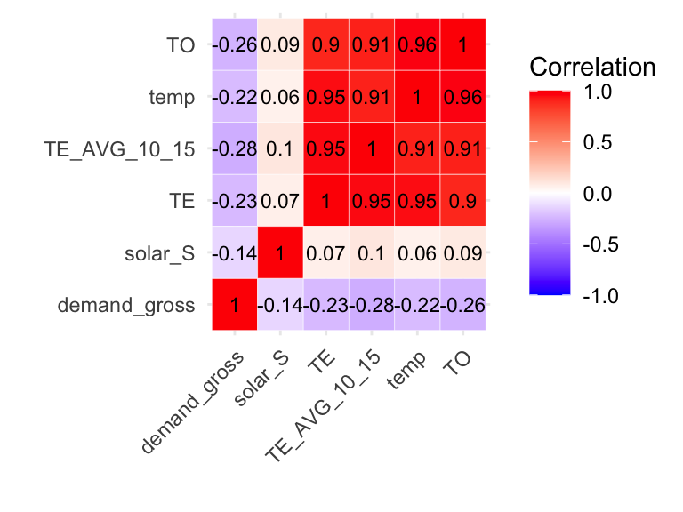

Figure 6: Correlation Heatmap with Temperature Data

# 3 Model fitting and cross-validation results

## 3.1 Model Introduction

All the models we constructed are linear regression models, and the model coefficients were estimated using the **multiple linear least squares method**. The **multiple linear least squares method** extends the ordinary least squares approach to cases where the dependent variable is influenced by multiple independent variables. Given a dataset with $n$ observations and $p$ predictors, the model is expressed as:
$$Y = X\beta
+\epsilon$$
where $Y$ is an $n\times1$ vector of observed responses, $X$ is an $n\times(p+1)$ matrix of predictors(including a column of ones for the intercept), $\beta$ is a $(p+1)\times 1$ vector of unknown coefficients, $\epsilon$ is an $n\times1$ vector of random errors.

The least squares solution minimizes the sum of squared residuals is:
$$S(\beta)=\sum_{i=1}^{n}(y_i-x_i^T\beta)^2.$$
The optimal coefficient estimates are obtained by solving the normal equation:
$$\hat{\beta} =
(X^TX)^{-1}X^TY$$
.

Next, we present the models we explored and the final selected model. First, we introduce the most fundamental linear regression model $M_0$. $M_0: Y_i=\beta_0+\beta_1wind_i+\beta_2solar\_S_i+\beta_3temp_i+\beta_4wdayindex_i+\beta_5monthindex_i+\epsilon_i$, where $\epsilon_i ～ \mathbf{N}(0,\sigma^2)$.Here $Y_i$ is the demand gross at time $i$, $\beta_j$,$j=1,...,5$ are the regression coefficients and $\epsilon_i$ is the error term at time $i$.

The multiple R-squared value is 0.4656, indicating that approximately 46.56% of the variation in electricity demand is explained by the predictors. While this suggests a moderate explanatory power, a significant portion of variability remains unexplained. The F-statistic (232.2, p-value < 2.2e-16) strongly supports the model’s overall significance, indicating that at least one predictor has a meaningful effect on demand_gross. Residual standard error (3747) suggests moderate dispersion around the fitted values, indicating that predictions may have some level of uncertainty.

## 3.2 Step-wise Model Refinement

Therefore, the next step is to develop a linear regression model that incorporates the influence of additional variables and thoroughly explore the role of each variable to maximize its utilization.

### 3.2.1 Step 1: Use More Variables

$$M_{01}: Y_i=\beta_0+\beta_1
wind_i+\beta_2solar\_S_i+\beta_3TE_i+\sum_j\beta_{4j}wdayindex_{ij}+\sum_{m}\beta_{6m}start\_year_{im}+\sum_v\beta_{7v}DSN_{iv}+\epsilon_i,$$
where $\epsilon_i ～ \mathbf{N}(0,\sigma^2)$.

In this model each term means:

Compared with $M_0$, we substitute variable **temp** with **TE** and add variables **start_year** and **DSN**, and the fitting result of this result shows that: the Multiple R-squared value of 0.9553 indicates that approximately 95.53% of the variation in the response variable is explained by the predictor variables. The Adjusted R-squared value of 0.9528 accounts for the number of predictors and sample size, suggesting that the model remains strong even after adjusting for potential overfitting. These values indicate a high degree of model fit, implying that the predictors effectively capture the underlying patterns in the data.

### 3.2.2 Step 2: Improvment about Data Solar-S

$$M_{02}: Y_i=\beta_0 + \beta_1 wind_i + \sum_{s} \beta_{2s}
solar\_category_{is} + \beta_3 TE_i + \sum_j \beta_{4j} wdayindex_{ij}
\\ + \sum_m \beta_{6m}start\_year_{im} + \sum_v \beta_{7v} DSN_{iv} +
\epsilon_i,$$
where $\epsilon_i ～ \mathbf{N}(0,\sigma^2)$.

In this model, we have changed variable:

- $\sum_{s} \beta_{2s} \cdot \text{solar_category}_{is}$: The effect of **solar power generation** categorized into three levels: “zero”, “low”, and “high”. As **solar_category** is a factor, the model will estimate separate coefficients for each level of the category, capturing how each level of solar energy production influences demand relative to the baseline category (usually “zero”).

After this change, we can see that the fitting result has a progress: The Multiple R-squared value of 0.9561 suggests that approximately 95.61% of the variability in the dependent variable is explained by the independent variables. This indicates a high explanatory power. The Adjusted R-squared value of 0.9537 accounts for the number of predictors and sample size, showing that the model remains robust even after adjusting for the degrees of freedom. Compared to the previous model (R² = 0.9553, Adjusted R² = 0.9528), this model exhibits a slight improvement, suggesting a better fit.

### 3.2.3 Step 3: Improvment about Data of Temperature TE(Goal5)

Table 1: Six Updated TE data and TE and TO

|  | Model | R2 | AdjR2 | AIC | BIC | Coefficient | P_Value | MSE | MAPE |
| --- | --- | --- | --- | --- | --- | --- | --- | --- | --- |
| TE_AVG_10_15 | TE Model | 0.9578 | 0.9555 | 58651.13 | 59795.87 | -519.43 | 0 | 1103296 | 1.55 |
| TE_MAX | TE Model | 0.9575 | 0.9551 | 58681.77 | 59826.50 | -509.57 | 0 | 1113055 | 1.57 |
| TE_AVG_5_20 | TE Model | 0.9566 | 0.9541 | 58755.29 | 59900.03 | -501.83 | 0 | 1136830 | 1.59 |
| TE | TE Model | 0.9561 | 0.9537 | 58789.94 | 59934.67 | -480.74 | 0 | 1148206 | 1.60 |
| TE_AVG | TE Model | 0.9556 | 0.9531 | 58832.66 | 59977.40 | -492.71 | 0 | 1162394 | 1.62 |
| TE_AVG_17_23 | TE Model | 0.9528 | 0.9502 | 59043.31 | 60188.04 | -462.97 | 0 | 1234948 | 1.68 |
| TE_MIN | TE Model | 0.9504 | 0.9477 | 59214.22 | 60358.96 | -453.73 | 0 | 1297134 | 1.74 |
| TO | TO Model | 0.9481 | 0.9452 | 59371.80 | 60516.54 | -370.84 | 0 | 1357237 | 1.78 |

First, we need to select an appropriate temperature variable, as discussed in Section 2.2.1. We substitute each of the six temperature variables into model $M_{02}$ and obtain a series of model characteristics, as shown in Table above. **TE_AVG_10_15** achieves the highest $R^2$ (0.9578) and Adjusted $R^2$ (0.9555), indicating that this model explains the largest proportion of variance in demand. Other variables, such as **TE_MAX** (0.9575) and **TE_AVG_5_20** (0.9566), also show strong performance but are slightly inferior. **TO** and **TE_MIN** have the lowest $R^2$ values (0.9481 and 0.9504, respectively), suggesting weaker explanatory power. Lower AIC and BIC values indicate better model fit with minimal complexity. **TE_AVG_10_15** has the lowest AIC (58651.13) and BIC (59795.87), suggesting the most optimal balance between model fit and complexity. **TE_MIN** and TO have the highest AIC (59214.22 and 59371.80) and BIC (60358.96 and 60516.54), implying these models may be overfitting or less efficient. **TE_AVG_10_15** achieves the lowest MSE (1,103,296) and MAPE (1.55), indicating the best predictive accuracy. **TE_MIN** also performs poorly, with MSE (1,297,134) and MAPE (1.74), suggesting it is not an optimal choice. Among all temperature variables, **TE_AVG_10_15** provides the best model performance, therefore, **TE_AVG_10_15** is the most suitable temperature variable for inclusion in the final model.

$$M_1: Y_i=\beta_0 + \beta_1 wind_i + \sum_{s} \beta_{2s}
solar\_category_{is} + \beta_3 \cdot TE\_AVG\_10\_15_i + \sum_j
\beta_{4j} wdayindex_{ij} \\+ \sum_m \beta_{6m} start\_year_{im} +
\sum_s \beta_{7s} DSN_{is} + \epsilon_i，$$
where $\epsilon_i ～ \mathbf{N}(0,\sigma^2)$.

In this model, we have changed variable:

- $\beta_3 \cdot \text{TE_AVG_10_15}_i$: The effect of the **temperature smoothing variable (TE_AVG_10_15)**, representing a smoothed average temperature between 10 AM and 3 PM. This variable accounts for temperature-related effects on electricity demand during the day.

After this change, we can see that the fitting result has a progress: $R^2 = 0.9578$ indicates that 95.78% of the variance in electricity demand is explained by the model’s independent variables. The Adjusted $R^2 = 0.9555$ accounts for the number of predictors and confirms that the model remains robust even after adjusting for complexity. The slight difference between R² and Adjusted R² suggests that the model includes relevant predictors without excessive overfitting. The model includes 183 predictors, meaning it incorporates a comprehensive set of factors influencing electricity demand. With 3295 residual degrees of freedom, the model is based on a sufficiently large dataset to ensure reliable estimation.

In the Figure 7, according to **Residuals vs Fitted** plot, we can see that the residuals are randomly distributed around zero, forming a cloud-like pattern with no apparent structure, which means that our model can fit the historical data well. However, in the **“Q-Q Residuals”** plot, we can see that the curve deviates from the diagonal at both ends, forming an **S-shape**. The reason why there has a S-shape here is that, we assumed that in our model, all of the residuals follow the normal distribution $\mathbf{N}(0,\sigma^2)$. However, in reality, these residuals have different variances, they do not follow the linear assumption.Therefore, to some extent, our assumption is incorrect—the linear assumption fails to adequately fit the data. In the **Scale-Location** plot, it plots the square root of the absolute standardized residuals on the y-axis against the fitted values on the x-axis. However the red line shows that, the residuals decrease as fitted values increase this indicates heteroscedasticity, meaning the variance of residuals is not constant. Which just fit the result from “Q-Q Residuals” plot.The **Residuals vs. Leverage** plot is used to detect influential observations that may disproportionately affect the regression model. It plots the standardized residuals on the y-axis against leverage values (a measure of how far an observation’s predictor values are from the mean) on the x-axis. The model appears to be relatively stable, with no strong signs of influential outliers.

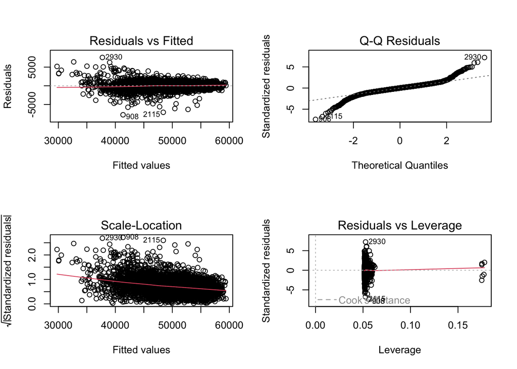

Figure 7: Four Features Figures of Model M1

### 3.2.4 Adding more Covariates

$$M_2: Y_i=\beta_0 + \beta_1wind_i + \sum_{s}
\beta_{2s}solar\_category_{is} + \beta_3temp_i^3 + \beta_4
TE\_AVG\_10\_15_i + \sum_{j} \beta_{5j} wdayindex_{ij} + \sum_{k}
\beta_{6k} monthindex_{ik}
\\+ \sum_m \beta_{7m} start\_year_{im} + \sum_v \beta_{8v}DSN_{iv} +
\beta_9 (TE\_AVG\_10\_15_i \times DSN_i) + \beta_{10} (temp_i \times
start\_year_i) + \epsilon_i$$
where $\epsilon_i ～ \mathbf{N}(0,\sigma^2)$.

In this model, we incorporated higher-order terms and covariates to capture more complex relationships and account for additional factors influencing the outcome：

After this change, we can see that the fitting result has a progress: This regression model performs exceptionally well with an $R^2$ of 96.22%, indicating that the independent variables explain most of the variation in electricity demand. The very small p-value from the F-statistic confirms that the model is statistically significant. The residual standard error of 1050 suggests that the model’s predictions are reasonably accurate, though there is room for minor improvements. Overall, this model provides a reliable framework for predicting electricity demand.

## 3.3 Model fitting results

### 3.3.1 Comparison Metrics

When evaluating and comparing the model’s fitting results, we consider three metrics: adjusted $R^2$, BIC.

**Adjusted** **$R^2$**: In regression analysis, the coefficient of determination $R^2$ quantifies how well the independent variables explain the variation in the dependent variable. However one major limitation of $R^2$ is that it tends to increase when additional predictors are added, even if those predictors contribute little to the model’s explanatory power, especially in Multiple Linear Regression model. To address this issue, the **Adjusted** **$R^2$** metric is introduced, which accounts for model complexity by incorporating degrees of freedom. The **Adjusted** **$R^2$** is computed as follows:
$$R_{adj}^2 = 1-(\frac{(1-R^2)(n-1)}{n-p-1}),$$
$R_{adj}^2$ will increase only if new added variables contribute significantly to the model, otherwise it may decrease, thus discouraging overfitting. It is a refined measure that provides a more reliable evaluation of a model’s predictive capability.

**BIC**(Bayesian Information Criterion): The **BIC** is a widely used criterion for model selection. It balances model fit and complexity, making it particularly useful in statistical modeling for selecting regression models. It aims to find an optimal model by penalizing excessice complexity while maintaing good data representation. It defined as:
$$BIC = -2lnL+klnn,$$
where $L$ is the maximum likelihood of the model,$k$ is the number of free parameters, $n$ is the sample size, $-2lnL$ measures goodness of fit, and $klnn$ is a penalty term that increases with the number of parameters, preventing overfitting. Since **BIC** imposes a stronger penalty on additional parameters compared to AIC(Akaike Information Criterion), it tends to favor simper models when the sample size is large. Which means this really suit our problem since the sample size is large in this question. Among competing models, the one with the smallest **BIC** value is preferred. **BIC** remains a fundamental criterion for model selection, particularly in cases where avoiding overfitting is a priority.

## 3.4 The Final Decison of the Model

The final model we selected is **$M_1$**：
$$M_1: Y_i=\beta_0 + \beta_1 wind_i + \sum_{s} \beta_{2s}
solar\_category_{is} + \beta_3 \cdot TE\_AVG\_10\_15_i + \sum_j
\beta_{4j} wdayindex_{ij} \\+ \sum_m \beta_{6m} start\_year_{im} +
\sum_s \beta_{7s} DSN_{is} + \epsilon_i，$$
Model **$M_2$** was included only as an experimental case, containing numerous unexplained interaction terms that significantly increase computational complexity while providing only a marginal improvement in adjusted $R^2$ . Therefore, **$M_2$** is not practically meaningful for use. In the following section, we provide a detailed analysis of the fitting results for Model **$M_1$**.

In Model M1, the intercept is 43,415.995, which includes the value of $\beta_0$ as well as the coefficients corresponding to the reference category (i.e., category labeled as 0) for categorical variables. The coefficient for **wind** is 518.077, a positive value, indicating that **wind** is positively correlated with **demand_gross**—an increase in wind speed is associated with higher peak electricity demand.

For the categorical variable **solar_category**, both **solar_categorylow(1)** and **solar_categoryhigh(2)** have positive coefficients, 542.236 and 615.309, respectively, suggesting that higher levels of solar activity are associated with increased electricity demand.

Additionally, the coefficient for **TE_AVG_10_15** is -519.463, indicating a negative correlation between temperature and peak electricity demand. This suggests that as temperature increases, the demand for electricity decreases.

This model has the fitting results adjusted $R^2$ 0.9555, which means the forecasted data are very close to real data. However based on “Q-Q plot”, we can conclude that this model has intrinsic problems since in the very beginning the assumption about the distribution of residual errors are wrong.

### 3.4.1 Model Fit to Historical Data(Goal2)

According to Table 2 and Figure 7, our Model can fit historical data well. It has adjusted $R^2$ of 0.9555.

More rigorously, based on Table 2, we have three new criterian to determine the fitting results with historical data, they are **RMSE**, **MAE** and **MAPE** respectively. Smaller values of RMSE, MAE, and MAPE denote superior predictive performance, with each metric offering unique insights into error magnitude and distribution. Based on the results of them, we can conclude that Model $M_1$ achieves reliable predictive accuracy with room for refinement, particularly in reducing absolute error magnitude while maintaining its excellent relative error performance. Analysis of Model $M_1$’s Fitting Performance:

1.Error Metric Performance: RMSE of 1050.392 and MAE of 726.6392 indicate moderate deviations between predicted and actual values and exceptionally low MAPE of 1.55% demonstrates excellent relative error control.

2.Performance Evaluation:The model demonstrates commendable predictive accuracy, particularly noting: MAPE below 2% is generally considered acceptable in practical applications and MAE/RMSE ratio ≈ 0.69 suggests relatively uniform error distribution without excessive outliers.

Table 2:Model M1 Performance Metrics

| Metric | Value |
| --- | --- |
| RMSE | 1050.39 |
| MAE | 726.64 |
| MAPE | 1.55 % |

Overall, based on the RMSE, MAE, and MAPE results, Model $M_1$ demonstrates high predictive accuracy, with consistently low error values across all metrics. The low MAPE (1.55%) indicates that the model effectively captures underlying data patterns with minimal relative error. This suggests that **$M_1$** is a relatively robust and reliable model for forecasting demand.

### 3.4.2 Comparation With M0 Model(Goal0)

Next, we will present the computation results of our two models, $M_0$ and $M_1$, based on these three criteria, along with a comparison table, as shown in Table 3. In our comparison, Model $M_0$ shows a relatively low adjusted $R^2$ of 0.4636 and $R^2$ of 0.4656, indicating that it explains only a small proportion of the variance in the dependent variable. Additionally, the model’s AIC and BIC values are significantly higher than those of $M_1$, at 67145.12 and 67237.44 respectively, which suggests poorer model fit. The residual standard error (RSE) of 3747.436 is also much larger in $M_0$, indicating substantial prediction error. The F-statistic of 232.1977 and the corresponding p-value of 0 imply that the model is statistically significant, but its performance is far from optimal compared to $M_1$.

On the other hand, Model $M_1$ demonstrates much stronger performance with an adjusted $R^2$ of 0.9555 and an $R^2$ of 0.9578, explaining over 95% of the variance in electricity demand. Its AIC and BIC values (58649.21 and 59787.79) are notably lower than those of $M_0$, indicating a better model fit. The residual standard error of 1079.321 confirms the much better predictive accuracy of $M_1$. The F-statistic of 409.0950, along with the p-value of 0, further reinforces the statistical significance of the model, demonstrating its superior performance.

Therefore, based on these criteria, Model $M_1$ clearly outperforms Model $M_0$ in terms of model fit, prediction accuracy, and statistical significance.

|  | Adj_R2 | R2 | AIC | BIC | Residual_SE | F_p_value |
| --- | --- | --- | --- | --- | --- | --- |
| M0 | 0.4636 | 0.4656 | 67145.12 | 67237.44 | 3747.436 | 0 |
| M1 | 0.9555 | 0.9578 | 58649.21 | 59787.79 | 1079.321 | 0 |

## 3.5 Model cross-validation results

### 3.5.1 The Cross-validation Results of Models

**K-fold Cross Validation**: K-fold cross-validation is a widely utilized technique for evaluating the performance and generalizability of predictive models. It helps to minimize the risk of overfitting, particularly when dealing with limited datasets. This method divides the data into $K$ subsets (folds),using each fold as a validation set while training on the remaining $K-1$ folds. This process is repeated $K$ times to ensure that each data point serves as a test point exactly once. The final criteria are **Squared Error(SE)**, **Dawid-Sebastiani(DS)** and **Interval Score(INT)**.

The K-fold cross-validation results of Models $M_0$, $M_1$, and $M_2$ are shown as Table 4. The table compares different models across three performance metrics: Squared Error, Dawid-Sebastiani Score, and Interval Score. Lower values indicate better model performance. From the table， we can observe that,Model M1 has the smallest **sqared error**, **Dawid-Sebastiani** and **Interval Score**. Which means M1 has the lowest squared error, suggesting it fits the data better than $M_0$ and $M_2$, $M_1$ and $M_2$ outperform $M_0$ significantly, with M1 slightly better than $M_2$ and $M_1$ provides the most accurate and confident prediction intervals.

Table 4: Model Performance Comparison Across Metrics

| order | Squared Error se_avg | Squared Error se_err | Dawid-Sebastiani ds_avg | Dawid-Sebastiani ds_err | Interval Score int_avg | Interval Score int_err |
| --- | --- | --- | --- | --- | --- | --- |
| M0 | 14105177 | 449995.56 | 17.463 | 0.032 | 19093.909 | 544.077 |
| M1 | 1241712 | 63326.29 | 15.033 | 0.052 | 6776.447 | 261.082 |
| M2 | 1259556 | 67469.52 | 15.038 | 0.053 | 6934.195 | 273.783 |

* Scores averaged across all predictions. Lower values indicate better performance.

### 3.5.2 Trade offs

Comparing models **$M_0$** and **$M_1$**, we observe that model **$M_1$** has a more complex structure than model **$M_0$**, incorporating additional variables that increase the complexity of $\hat{\beta}$ and add to the computational burden. Moreover, the data required for model **$M_1$** is more challenging to process than that for model **$M_0$**, particularly when refining **TE** data, which must be extracted from a large dataset `SCS_hourly_temp`, undergo preprocessing, and then be further processed through additional calculations. Comparing models **$M_2$** and **$M_1$**, we can notice that the structure of model **$M_2$** is much complicated than model **$M_1$** since it has covariates and high-degree terms. So even though model **$M_2$** performs better in adjusted $R^2$, we will still give up this model since the improvement in model fit is insufficient to justify its increased complexity, and given the inherent estimation issues—such as the inclusion of multiple temperature-related variables leading to multicollinearity—the model exhibits unstable parameter estimates.

## 3.6 The Prediction accuracy in Different Months(Goal3)

The chart below shows the RMSE (Root Mean Square Error) of peak electricity demand predictions for different months, along with their 95% confidence intervals. Here are some key insights:

1.Comparison of Errors Across Months: Months with higher RMSE (e.g., January, March, and December ) indicate that the model has larger prediction errors during these periods. Months with lower RMSE (e.g., February and November) suggest that the model performs more accurately during these times.

2.Impact of Confidence Intervals: Wider confidence intervals (e.g., in March and December) indicate higher uncertainty in predictions, possibly due to greater variability in data or poorer model adaptation to these months. Narrower confidence intervals (e.g., in February and November) suggest more stable and reliable predictions with less variance.

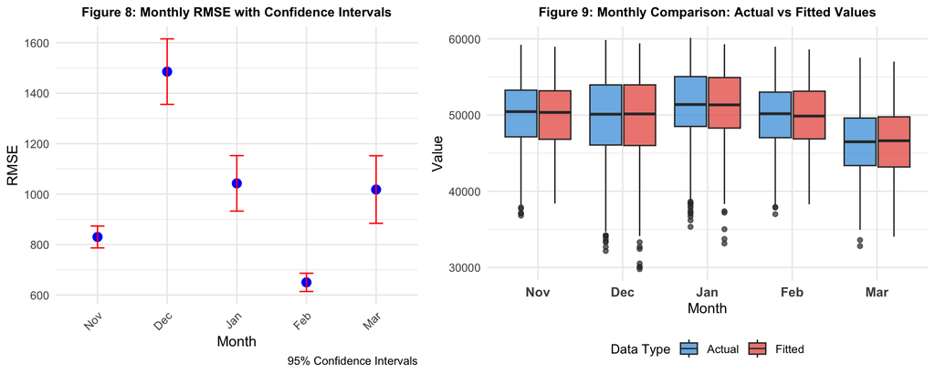

Based on Figure 9, the higher error in December may be attributed to two main factors: First, the inherent variability in December’s data distribution likely leads to less precise fitted results. Second, the combined effects of numerous UK holidays and reduced working days during this month cause greater fluctuations in peak electricity demand. Our model’s inability to quantify holiday-related impacts may contribute to its poorer predictive performance in December.

## 3.7 The Affect of Weather Conditions in Maximum Annual Demand in 2013-14 Winter Season(Goal4)

First, we define the winter season in the UK as beginning on November 1st and ending on March 31st of the following year. Our objective is to investigate the impact of winter weather conditions on peak annual electricity demand. Specifically, we aim to analyze how changes in weather conditions would affect peak electricity demand during the 2013–2014 winter season.

To address temporal dependence, we apply the **block bootstrap method**, which preserves the data’s temporal structure by resampling blocks of consecutive observations. The data is divided into non-overlapping blocks of size **B**, and **m** blocks are randomly resampled to form a bootstrap sample. This process is repeated **B** times to generate a distribution of bootstrap statistics for inference. Block bootstrap is particularly useful when data exhibits temporal or spatial dependence, as it maintains the correlation structure within the data while resampling.

Based on the previous analysis, we select a block size of 7 and calculate the predictive distribution for gross demand using weather data from different years. The resulting predictions are presented along with their associated upper and lower bounds.

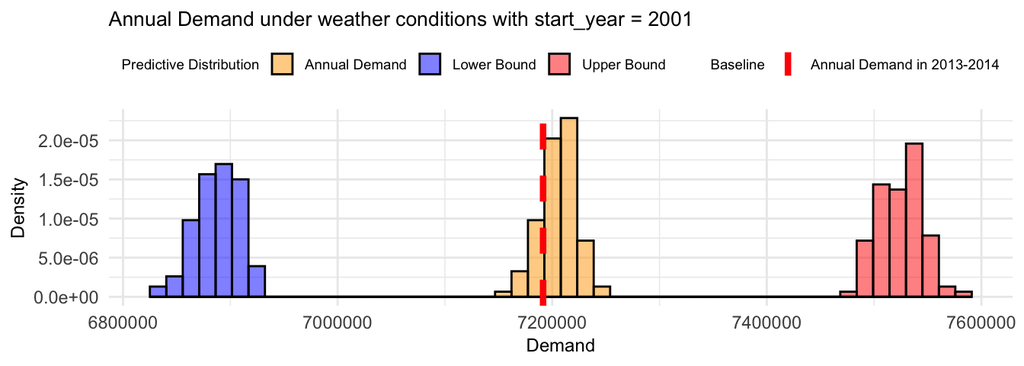

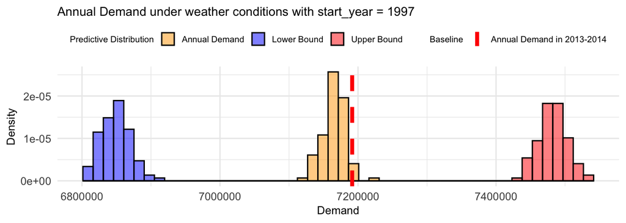

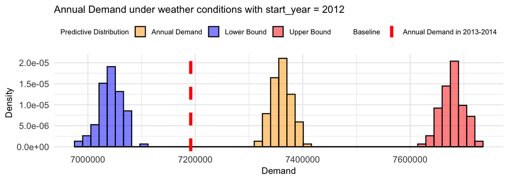

Table 5 shows the entire experiment results. The start year ranges from 1991 to 2013, and we use the mode to represent the predictive distribution, along with the corresponding lower and upper bounds. From the table, we can see that in the earlier years, the annual demand tended to be higher than the baseline, probably due to lower temperatures. More recent years show fluctuation around the baseline, suggesting an unstable weather condition. Based on our analysis, we conclude that weather conditions, specifically temperature, have a significant impact on the annual demand. Lower temperatures may lead to higher demand, while fluctuations in temperature from year to year can result in varying levels of demand. Further exploration into the effects of weather conditions on demand gross could provide valuable insights for future forecasting models.

Table 5: Change in Damand Gross 2013-14 when using weather data from other years

| Year | Annual_Demand | Lower_Bound | Upper_Bound | label |
| --- | --- | --- | --- | --- |
| 1991 | 7,268,248 | 6,960,734 | 7,586,154 | bigger |
| 1992 | 7,278,061 | 6,949,155 | 7,583,847 | bigger |
| 1993 | 7,324,071 | 6,989,003 | 7,640,993 | bigger |
| 1994 | 7,210,675 | 6,894,624 | 7,529,393 | bigger |
| 1995 | 7,355,499 | 7,043,757 | 7,663,536 | bigger |
| 1996 | 7,288,075 | 6,976,995 | 7,606,217 | bigger |
| 1997 | 7,166,643 | 6,847,910 | 7,479,663 | smaller |
| 1998 | 7,243,173 | 6,927,174 | 7,562,513 | bigger |
| 1999 | 7,216,815 | 6,904,822 | 7,534,073 | bigger |
| 2000 | 7,318,800 | 6,987,480 | 7,619,784 | bigger |
| 2001 | 7,211,501 | 6,899,950 | 7,532,464 | bigger |
| 2002 | 7,205,673 | 6,890,675 | 7,519,585 | bigger |
| 2003 | 7,212,392 | 6,889,444 | 7,532,709 | bigger |
| 2004 | 7,195,743 | 6,884,351 | 7,525,791 | similar |
| 2005 | 7,289,723 | 6,982,654 | 7,611,456 | bigger |
| 2006 | 7,122,791 | 6,813,933 | 7,447,143 | smaller |
| 2007 | 7,195,313 | 6,870,410 | 7,513,110 | similar |
| 2008 | 7,285,091 | 6,963,681 | 7,620,804 | bigger |
| 2009 | 7,338,171 | 7,019,197 | 7,661,020 | bigger |
| 2010 | 7,317,956 | 6,997,805 | 7,634,282 | bigger |
| 2011 | 7,132,087 | 6,813,087 | 7,446,484 | smaller |
| 2012 | 7,366,283 | 7,050,496 | 7,677,398 | bigger |
| 2013 | 7,193,784 | 6,881,685 | 7,519,956 | similar |

# 4 Conslusion

## 4.1 The Summary of Key Conclusions

1.**start_year** coefficients highlight how demand evolves year by year, e.g. by 2013 the offset is +3764 (MW) from the 1991 baseline.

3.Electricity demand exhibits a weekly cycle, with lower peak demand on Saturdays and Sundays, and higher peak demand from Monday to Friday.

4.**wind** and **solar_category** are positively correlated with **demand_gross**, while **TE_AVG_10_15** is negatively correlated. This indicates that stronger wind and solar-related factors, along with lower temperatures, are associated with higher peak electricity demand.

### 4.1.1 Predictive Performance of the Final Model

In Model $M_1$, the intercept (43,415.995) represents $\beta_0$ along with the baseline category effects for categorical variables. The wind coefficient (518.077) indicates a positive correlation with demand_gross, meaning higher wind speeds correspond to increased peak electricity demand.

For solar_category, both solar_categorylow(1) (542.236) and solar_categoryhigh(2) (615.309) have positive coefficients, suggesting that greater solar activity is linked to higher demand. Conversely, TE_AVG_10_15 has a negative coefficient (-519.463), implying that rising temperatures reduce peak electricity demand.

With an adjusted $R^2$ of 0.9555, the model closely aligns with observed data. However, the Q-Q plot reveals deviations from normality in residuals, suggesting violations of underlying distributional assumptions.

### 4.1.2 Reliability of the Final Model

Overall, based on the RMSE, MAE, and MAPE results, Model $M_1$ demonstrates high predictive accuracy, with consistently low error values across all metrics. The low MAPE (1.55%) indicates that the model effectively captures underlying data patterns with minimal relative error. This suggests that $M_1$ is a robust and reliable model for forecasting demand.

### 4.1.3 Practical Relevance for NESO

Based on the data results, it can be reasonably concluded that the maximum electricity demand tends to be higher during working hours compared to non-working hours. Therefore, in the future, Neso could consider adjusting the power supply during holidays by reducing the electricity distribution in response to the lower demand. This approach would not only optimize the utilization of resources but also contribute to more sustainable energy management, ensuring that supply aligns more closely with actual consumption patterns during peak and off-peak periods.

It is advisable to enhance the monitoring of temperature, as it has a significant impact on the maximum electricity demand. Temperature fluctuations, especially during extreme heat or cold conditions, can lead to substantial increases in electricity consumption due to heightened demand for heating or cooling. By incorporating more precise and real-time temperature data into demand forecasting models, it would be possible to better predict electricity usage patterns and improve the efficiency of energy distribution. This proactive approach could help mitigate the risk of supply shortages and allow for more effective demand-side management, ultimately promoting a more responsive and adaptive energy system.

## 4.2 Model Assumptions

1.Assume that the error terms are linearly independent and follow a normal distribution.It ensures the validity of inferential statistics, such as hypothesis testing and confidence intervals, and facilitates the estimation of model parameters.

2.Assume that the data **solar_S**, **wind**,etc. are stationary. It ensures that the statistical properties of the data, such as mean and variance, do not change over time. This consistency allows for reliable model estimation and valid inference, as non-stationary data can lead to spurious relationships and biased parameter estimates.

3.Assume that the peak electricity demand occurs at 6 PM. This time is characterized by the highest consumption levels, which is crucial for predicting daily electricity demand patterns.

4.Assume that all variables are independent. This assumption simplifies the model by treating each predictor as having no correlation with the others, allowing for clearer interpretation of their individual contributions to the prediction of peak demand.

## 4.3 The limitations of the Model(Goal6)

1.One limitation of the model is the assumption that the error terms are linearly independent and follow a normal distribution. In practice, this assumption may not always hold. Factors such as unobserved variables, temporal dependencies, or heteroscedasticity can introduce correlations among errors or cause deviations from normality, which can impact the validity of statistical inferences, potentially leading to biased parameter estimates and unreliable confidence intervals.

2.Another limitation of the model is its exclusion of external factors such as technological advancements, economic fluctuations, demographic changes, and policy shifts. These variables can significantly influence electricity demand over time. For instance, advancements in energy-efficient technologies or shifts toward electrification in various sectors may alter consumption patterns.

3.The third limitation of regression models in this case (time-dependent) is their assumption of a fixed relationship between independent and dependent variables, often treating input features as independent and identically distributed (i.i.d.). This overlooks temporal dependencies, seasonal patterns, and long-term trends, reducing the model’s ability to capture dynamic and complex behaviors over time.

To refine the limitations above, time series models, such as ARIMA, SARIMA, and Exponential Smoothing, are specifically designed to handle temporal dependencies and patterns within data. Unlike regression models, these models are capable of capturing trends, seasonality, and autocorrelation, making them better suited for forecasting in contexts where such patterns are prevalent. Given the nature of electricity demand, which often exhibits strong seasonal fluctuations and long-term trends, time series models may provide more accurate predictions by effectively modeling these inherent temporal structures.

## 4.4 How the Model Supports NESO’s Long-Term Planning Goals

1.Quantifying Uncertainty in Peak Demand: Our probabilistic forecasts quantify uncertainty in peak demand, enabling NESO to assess scenario likelihoods and make informed infrastructure decisions. This helps balance the risks of over- or under-building, improving long-term energy reliability and efficiency.

2.Optimizing Infrastructure Investment: By forecasting long-term peak demand, our model helps NESO identify when and where new infrastructure is needed, guiding strategic investment in high-growth regions. This proactive, data-driven approach enhances planning efficiency and supports a more resilient, cost-effective energy system.

3.Enhancing Risk Management: By predicting peak demand and its uncertainty, our model enables NESO to better manage risk through probabilistic forecasts. This supports informed decisions on backup supply, load balancing, and contingency planning, enhancing grid stability and reducing the need for emergency interventions.

# 5 Code Appendix

Include here all the code used in your analysis. Ensure that the code is well-commented so it is easy to follow and reuse.

```r
# Load required libraries
knitr::opts_chunk$set(echo = TRUE)
library(tidyverse)
library(readr)
library(dplyr)
library(ggplot2)
library(knitr)
library(kableExtra)
library(vcd)
library(boot)
library(htmltools)
library(flextable)

## Tidying data
## load data to data frame 1 and 2
## clean the data
data1 <- read.csv("SCS_demand_modelling.csv")
data_temp <- read.csv("SCS_hourly_temp.csv")

head(data1)

## Transfering data for calculation

data1$wdayindex <- as.factor(data1$wdayindex)
data1$monthindex <- as.factor(data1$monthindex)
data1$DSN <- as.factor(data1$DSN)
data1$start_year <- as.factor(data1$start_year)

# Divide Date into Day-Month-Year
# Transfer type String into POSIXct type
data_temp$Date <- as.POSIXct(data_temp$Date, format = "%d/%m/%Y %H:%M")
# Extract day
data_temp$day <- format(data_temp$Date, "%Y-%m-%d")
# Transfer to same type
data1$Date <- as.Date(data1$Date)

data_temp$day <- as.Date(data_temp$day)
# Select temperature in the range of date from the data file
data_temp_filtered <- data_temp[data_temp$day %in% data1$Date, ]

# construct the improved model
solar_threshold <- quantile(data1$solar_S[data1$solar_S > 0], 0.5)
data1$solar_category <- cut(data1$solar_S,
                            breaks = c(-Inf, 0, solar_threshold, Inf),
                            labels = c("zero", "low", "high"))

# Create a data frame for daily temperature
df_daily <- data_temp_filtered %>%
  # Extract hour information for analysis
  mutate(hour = as.numeric(format(Date, "%H"))) %>%
  # group by day
  group_by(day) %>%
  # calculate everyday temperature measure
  summarise(
    # calculate the average temperature between 10a.m. and 15p.m.(peak during morning)
    T_AVG_10_15 = mean(temp[hour %in%10:15], na.rm = TRUE),
    # calculate the average temperature between 17a.m. and 23p.m.(peak during night)
    T_AVG_17_23 = mean(temp[hour %in%17:23], na.rm = TRUE),
    # calculate the average temperature between 5a.m. and 20p.m.(peak during the day)
    T_AVG_5_20 = mean(temp[hour >= 5 & hour <= 20], na.rm = TRUE),
    # calculate the highest temperature for a day
    T_MAX = max(temp, na.rm = TRUE),
    # calculate the lowest temperature for a day
    T_MIN = min(temp, na.rm = TRUE),
    # calculate the average temperature for a day
    T_AVG = mean(temp, na.rm = TRUE)
  ) %>%
  ungroup() %>%
  # arrange by day
  arrange(day)

# initialize the value of TE
# Create an empty column to store the smoothed temperature values
df_daily$TE_AVG_10_15 <- NA_real_
df_daily$TE_AVG_17_23 <- NA_real_
df_daily$TE_AVG_5_20 <- NA_real_
df_daily$TE_MAX <- NA_real_
df_daily$TE_MIN <- NA_real_
df_daily$TE_AVG <- NA_real_

# set initial value
init_val <- 11.3652008

# give initial value for the first day
df_daily$TE_AVG_10_15[1] <- init_val
df_daily$TE_AVG_5_20[1] <- init_val
df_daily$TE_AVG_17_23[1] <- init_val
df_daily$TE_MAX[1] <- init_val
df_daily$TE_MIN[1] <- init_val
df_daily$TE_AVG[1] <- init_val

# Using TE to compute smoothed daily temperature values using an exponential smoothing algorithm
# Formula: Smoothed value of the current day = (Actual value of the current day + Smoothed value of the previous day) / 2
for (i in 2 : nrow( df_daily ) ) {
  # Compute the smoothed value for the average temperature between 10 AM and 3 PM
  df_daily$TE_AVG_10_15[i] <- (df_daily$T_AVG_10_15[i] + df_daily$TE_AVG_10_15[i-1]) / 2
  # Compute the smoothed value for the average temperature between 5 AM and 8 PM
  df_daily$TE_AVG_5_20[i] <- (df_daily$T_AVG_5_20[i] + df_daily$TE_AVG_5_20[i-1]) / 2
  # Compute the smoothed value for the average temperature between 5 PM and 11 PM
  df_daily$TE_AVG_17_23[i] <- (df_daily$T_AVG_17_23[i] + df_daily$TE_AVG_17_23[i-1]) / 2
  # Compute the smoothed value for the maximum temperature
  df_daily$TE_MAX[i] <- (df_daily$T_MAX[i] + df_daily$TE_MAX[i-1]) / 2
  # Compute the smoothed value for the minimum temperature
  df_daily$TE_MIN[i] <- (df_daily$T_MIN[i] + df_daily$TE_MIN[i-1]) / 2
  # Compute the smoothed value for the average temperature
  df_daily$TE_AVG[i] <- (df_daily$T_AVG[i] + df_daily$TE_AVG[i-1]) / 2
}

# Data merging
# Merge the original data with the processed temperature data, matching by date
data1 <- data1 %>%
  left_join(df_daily, by = c("Date" = "day"))

## Before building models, we want to decide which variables be the explanatory variables
# Select the specified variables
selected_vars <- c("demand_gross", "temp", "TO", "TE", "solar_S")

# Filter only existing variables
existing_vars <- selected_vars[selected_vars %in% names(data1)]

# Create correlation matrix
cor_matrix <- data1 %>%
  select(all_of(existing_vars)) %>%
  cor(use = "pairwise.complete.obs")

# Convert to long format for ggplot
cor_data <- cor_matrix %>%
  as.data.frame() %>%
  mutate(Var1 = rownames(.)) %>%
  pivot_longer(cols = -Var1, names_to = "Var2", values_to = "Correlation")


## use box plots to examine demand trends across different time scales and categorical groupings
# Day of Week plot with explicit boundaries
figure1 <- ggplot(data1, aes(x = wdayindex, y = demand_gross)) +
  geom_boxplot(
    fill = "lightblue",
    color = "blue",
    outlier.color = "red",          # Color for outliers
    outlier.shape = 16,             # Solid dots for outliers
    coef = 1.5                      # Explicit IQR multiplier for whiskers
  ) +
  stat_boxplot(
    geom = "errorbar",              # Adds the T-shaped ends to whiskers
    width = 0.2,
    color = "blue"
  ) +
  labs(
    title = "Figure1: Electricity Demand by Day of Week",
    subtitle = "Box boundaries: 25th-75th percentiles | Whiskers: 1.5×IQR range",
    x = "Day of Week",
    y = "Demand (Gross)"
  ) +
  theme_minimal() +
  theme(
    plot.title = element_text(size = 10, face = "bold"),
    plot.subtitle = element_text(size = 8, color = "gray"),
    axis.text = element_text(size = 10),
    panel.grid.major.x = element_blank(),
    plot.margin = margin(5,15,5,5)
  ) +
  scale_y_continuous(labels = scales::comma)


## Select five days in winter period to illustrate diurnal cycles
# Filter for winter months (Nov-Mar: monthindex 11,0,1,2,3)
# Convert Date to POSIXct format and extract components
data_temp$DateTime <- as.POSIXct(data_temp$Date, format = "%Y-%m-%d %H:%M:%S")
```

```r
# Extract month (1-12) and hour (0-23) using base R functions
data_temp$Month <- as.integer(format(data_temp$DateTime, "%m"))
data_temp$Hour <- as.integer(format(data_temp$DateTime, "%H"))

# Convert day to Date format
data_temp$Day <- as.Date(data_temp$day)

# Filter for winter months (Nov=11, Dec=12, Jan=1, Feb=2, Mar=3)
winter_temp <- data_temp[data_temp$Month %in% c(11, 12, 1, 2, 3), ]

# Create month names
winter_temp$Month_Name <- factor(winter_temp$Month,
                                 levels = c(11, 12, 1, 2, 3),
                                 labels = c("November", "December", "January", "February", "March"))

# Set random seed for reproducibility
set.seed(123)

# Set random seed for reproducibility
set.seed(123)
unique_days <- unique(winter_temp$Day)
selected_days <- sample(unique_days, 5)

# Filter for selected days
plot_data <- winter_temp[winter_temp$Day %in% selected_days, ]
# Create date labels for legend
plot_data$Date_Label <- format(plot_data$Day, "%Y-%m-%d")

# 创建ggplot2版本的温度图
figure2 <- ggplot(plot_data, aes(x = Hour, y = temp, color = Date_Label, group = Date_Label)) +
  geom_line(size = 1) +
  geom_point() +
  scale_color_manual(values = c("blue", "orange", "green", "red", "purple")) +
  labs(
    title = "Figure 2:Hourly Temperature Patterns for 5 Random Days",
    x = "Hour of Day",
    y = "Temperature (°C)"
  ) +
  theme_minimal() +
  scale_x_continuous(breaks = seq(0, 23, by = 3), labels = paste0(seq(0, 23, by = 3), ":00")) +
  theme(
    legend.position = "right",
    legend.title = element_text(size = 9),
    panel.grid.minor = element_blank(),
    plot.margin=margin(5,5,5,15),
    plot.title = element_text(size = 10, face = "bold"),
    plot.subtitle = element_text(size = 8, color = "gray")
  )

layout <- rbind(c(1,2))
grid.arrange(figure1, figure2, layout_matrix=layout, widths=c(3.5,5),heights=1)


# Create the heat map
ggplot(cor_data, aes(Var1, Var2, fill = Correlation)) +
  geom_tile(color = "white") +
  scale_fill_gradient2(low = "blue", mid = "white", high = "red",
                       midpoint = 0, limit = c(-1, 1), space = "Lab") +
  geom_text(aes(label = round(Correlation, 2)), color = "black", size = 3) +
  theme_minimal() +
  labs(#title = "Correlation Heatmap of Demand Predictors",
    x = "", y = "") +
  theme(axis.text.x = element_text(angle = 45, hjust = 1, vjust = 1),
        panel.grid.major = element_blank(),
        panel.border = element_blank(),
        panel.background = element_blank(),
        axis.ticks = element_blank())


# Perform a Chi-square test to analyze the relationship between month index and DSN
suppressWarnings(chisq.test(table(data1$monthindex, data1$DSN)))


# Create the plot with modified x-axis ordering
figure4 <- ggplot(data1, aes(x = factor(monthindex,
                                        levels = c(3:11, 0:2),  # New order: Mar-Nov, then Dec-Feb
                                        labels = c("Mar (3)", "Apr (4)", "May (5)",
                                                   "Jun (6)", "Jul (7)", "Aug (8)",
                                                   "Sep (9)", "Oct (10)", "Nov (11)",
                                                   "Dec (0)", "Jan (1)", "Feb (2)")),
                             y = demand_gross)) +
  geom_boxplot(
    fill = "lightgreen",
    color = "darkgreen",
    outlier.color = "red",
    outlier.shape = 16,
    coef = 1.5
  ) +
  stat_boxplot(
    geom = "errorbar",
    width = 0.2,
    color = "darkgreen"
  ) +
  scale_x_discrete(
    labels = c("3" = "Mar (3)", "4" = "Apr (4)", "5" = "May (5)",
               "6" = "Jun (6)", "7" = "Jul (7)", "8" = "Aug (8)",
               "9" = "Sep (9)", "10" = "Oct (10)", "11" = "Nov (11)",
               "0" = "Dec (0)", "1" = "Jan (1)", "2" = "Feb (2)")
  ) +
  labs(
    title = "Figure 4: Electricity Demand by Month",
    subtitle = "Months ordered: Mar(3)-Nov(11) followed by Dec(0)-Feb(2)",
    x = "Month (Index)",
    y = "Demand (Gross)"
  ) +
  theme_minimal() +
  theme(
    plot.title = element_text(size = 10, face = "bold"),
    plot.subtitle = element_text(size = 5, color = "gray"),
    axis.text.x = element_text(angle = 45, hjust = 1, size = 10),
    axis.text.y = element_text(size = 10),
    panel.grid.major.x = element_blank()
  ) +
  scale_y_continuous(labels = scales::comma)

selected_dsns <- sample(unique(data1$DSN), 20)

# Filter and plot
figure5 <- data1 %>%
  filter(DSN %in% selected_dsns) %>%
  ggplot(aes(x = factor(DSN), y = demand_gross)) +
  geom_boxplot() +
  labs(title = "Figure 5: Gross Demand for Randomly Selected DSN Values",
       x = "DSN",
       y = "Gross Demand") +
  theme(axis.text.x = element_text(angle = 45, hjust = 1),
        plot.title = element_text(size = 10, face = "bold"),
        plot.subtitle = element_text(size = 5, color = "gray"))

layout <- rbind(c(1,2))
grid.arrange(figure4, figure5, layout_matrix=layout, widths=c(3.5,5),heights=1)


# 4. Prepare variables for correlation analysis
cor_data <- data1 %>%
  select(demand_gross, temp = T_AVG, TO, TE = TE_AVG, solar_S, TE_AVG_10_15)

# 5. Create correlation matrix
cor_matrix <- cor(cor_data, use = "pairwise.complete.obs")

# 6. Plot heatmap
cor_matrix %>%
  as.data.frame() %>%
  mutate(Var1 = rownames(.)) %>%
  pivot_longer(cols = -Var1, names_to = "Var2", values_to = "Correlation") %>%
  ggplot(aes(Var1, Var2, fill = Correlation)) +
  geom_tile(color = "white") +
  scale_fill_gradient2(low = "blue", mid = "white", high = "red",
                       midpoint = 0, limit = c(-1, 1)) +
  geom_text(aes(label = round(Correlation, 2)), color = "black", size = 3) +
  theme_minimal() +
  labs(x = "", y = "") +
  theme(axis.text.x = element_text(angle = 45, hjust = 1))


## Now we set the model for simulation and prediction to find the most fitted one
# construct the given basic model
M0 <- lm(demand_gross ~ wind + solar_S + temp + wdayindex + monthindex , data = data1)
summary(M0)


M01 <- lm(demand_gross ~ wind + solar_S + TE  +
            wdayindex + start_year + DSN,data = data1)
```

```r
# Generate basic model summary
summary(M01)


M02 <- lm(demand_gross ~
            wind + solar_category + TE
          + wdayindex + start_year + DSN, data = data1)


# Generate basic model summary
summary(M02)


# List of temperature variables to test
temp_vars <- c("TO","TE","TE_AVG_10_15", "TE_AVG_5_20", "TE_AVG_17_23",
               "TE_MAX", "TE_MIN", "TE_AVG")

# Create dataframe to store model comparison results
model_results <- data.frame(
  Model = character(),
  R2 = numeric(),          # R-squared
  AdjR2 = numeric(),       # Adjusted R-squared
  AIC = numeric(),         # Akaike Information Criterion
  BIC = numeric(),         # Bayesian Information Criterion
  Coefficient = numeric(), # Coefficient of temperature variable
  P_Value = numeric(),     # Significance of temperature variable
  MSE = numeric(),         # Mean Squared Error
  MAPE = numeric(),        # Mean Absolute Percentage Error
  stringsAsFactors = FALSE
)

# Base model formula without specific temperature variable
base_formula <- "demand_gross ~ wind + solar_category + TE + wdayindex + monthindex + start_year + DSN"

# Loop through each temperature variable to build and evaluate models
for (temp_var in temp_vars) {
  # Create descriptive model name
  model_name <- paste0(sub("_.*$", "", temp_var), " Model")

  # Update formula with current temperature variable
  current_formula <- gsub("TE", temp_var, base_formula)

  # Fit linear model
  current_model <- lm(as.formula(current_formula), data = data1)

  # Get model summary
  model_summary <- summary(current_model)

  # Extract coefficient and p-value for temperature variable
  temp_index <- which(names(coefficients(current_model)) == temp_var)
  if (length(temp_index) == 0) {
    coefficient <- NA
    p_value <- NA
  } else {
    coefficient <- coefficients(current_model)[temp_index]
    p_value <- model_summary$coefficients[temp_index, 4]
  }

  # Calculate predictions
  predictions <- predict(current_model, newdata = data1)

  # Calculate Mean Squared Error
  mse <- mean((data1$demand_gross - predictions)^2, na.rm = TRUE)

  # Calculate Mean Absolute Percentage Error
  # Using pmax() to avoid division by zero
  actual <- data1$demand_gross
  mape <- mean(abs((actual - predictions) / pmax(abs(actual), 1e-10)) * 100, na.rm = TRUE)

  # Store results
  model_results <- rbind(model_results, data.frame(
    Model = model_name,
    R2 = model_summary$r.squared,
    AdjR2 = model_summary$adj.r.squared,
    AIC = AIC(current_model),
    BIC = BIC(current_model),
    Coefficient = coefficient,
    P_Value = p_value,
    MSE = mse,
    MAPE = mape
  ))
}

# Format results for display
model_results$R2 <- round(model_results$R2, 4)
model_results$AdjR2 <- round(model_results$AdjR2, 4)
model_results$AIC <- round(model_results$AIC, 2)
model_results$BIC <- round(model_results$BIC, 2)
model_results$Coefficient <- round(model_results$Coefficient, 2)
model_results$P_Value <- round(model_results$P_Value, 4)
model_results$MSE <- round(model_results$MSE, 2)
model_results$MAPE <- round(model_results$MAPE, 2)

# Sort models by R-squared (descending)
model_results <- model_results[order(-model_results$R2), ]

# Identify best performing models for each metric
best_r2 <- which.max(model_results$R2)
best_adj_r2 <- which.max(model_results$AdjR2)
best_aic <- which.min(model_results$AIC)
best_bic <- which.min(model_results$BIC)
best_mse <- which.min(model_results$MSE)
best_mape <- which.min(model_results$MAPE)

knitr::kable(model_results,caption = "Table 1: Six Updated TE data and TE and TO ")


M1 <- lm(demand_gross ~ wind + solar_category +
           TE_AVG_10_15 + wdayindex + start_year +
           DSN, data = data1)


# Generate basic model summary
summary(M1)

# Generate diagnostic plots
par(mfrow = c(2, 2))
plot(M1)


M2 <- lm(demand_gross ~
           wind + solar_category  +I(temp^3) +
           TE_AVG_10_15 * DSN  +  TO +  temp:start_year +
           wdayindex + start_year, data = data1)


# Generate basic model summary
summary(M2)


## Question 2
# Calculate common error metrics
actual <- data1$demand_gross
predicted <- fitted(M1)

# Root Mean Squared Error - measures average squared difference between predicted and actual values
rmse <- sqrt(mean((actual - predicted)^2))

# Mean Absolute Error - measures average absolute difference
mae <- mean(abs(actual - predicted))

# Mean Absolute Percentage Error - measures percentage difference
mape <- mean(abs((actual - predicted)/actual)) * 100

# Print results
# cat("Model M1 Performance Metrics:\n")
# cat("RMSE:", rmse, "\n")       # Lower is better
# cat("MAE:", mae, "\n")         # Lower is better
# cat("MAPE:", mape, "%\n")      # Lower is better (<10% excellent, <20% good)

# Create a data frame of metrics
metrics_df <- data.frame(
  Metric = c("RMSE", "MAE", "MAPE"),
  Value = c(rmse, mae, mape)
)

# Optionally format MAPE with % symbol
metrics_df$Value <- ifelse(metrics_df$Metric == "MAPE",
                           paste0(round(metrics_df$Value, 2), " %"),
                           round(metrics_df$Value, 2))

# Display the table
kable(metrics_df, caption = "Table 2:Model M1 Performance Metrics")



## We find the most suitable model is M1, so we make a table to compare M0 and M1
# Extract model metrics
get_model_stats <- function(model) {
  s <- summary(model)
  data.frame(
    Adj_R2 = s$adj.r.squared,
    R2 = s$r.squared,
    AIC = AIC(model),
    BIC = BIC(model),
    Residual_SE = sigma(model),
    F_p_value = pf(s$fstatistic[1], s$fstatistic[2], s$fstatistic[3], lower.tail = FALSE)
  )
}

# Compare M0 and M1
model_comparison <- rbind(
  M0 = get_model_stats(M0),
  M1 = get_model_stats(M1)
)

# Create nicely formatted table
kable(model_comparison,
      digits = 4,
      caption = "Table 3: Model Comparison: M0 vs. M01",
      align = c('l', 'r', 'r'),  # Left align first column, right align others
      format = "simple")  # Use "simple" format for console output+6


# Use K-Fold Cross Validation to show how well the model performce
# K-Fold Cross Validation
set.seed(123)
k <- 10  # Number of folds
n <- nrow(data1)
fold_indices <- sample(rep(1:k, length.out = n)) # Assign fold numbers randomly
```

```r
# Define models
Flist <- list(M0, M1, M2)

# Function for k-fold CV
cross_validate <- function(model, data, k, model_name) {
  lapply(1:k, function(i) {
    # Split data
    test_indices <- which(fold_indices == i)
    train_data <- data[-test_indices, ]
    test_data <- data[test_indices, ]

    # Fit model (use update to keep original formula)
    current_model <- update(model, data = train_data)

    # Predict
    prediction <- predict.lm(object = current_model, newdata = test_data,
                             se.fit = TRUE, interval = "prediction", level = 0.95)

    # Create results data frame
    pred <- test_data
    pred$mean <- prediction$fit[,1]
    pred$sd <- sqrt(prediction$se.fit^2 + prediction$residual.scale^2)
    pred$lwr <- prediction$fit[,1] - 1.96*pred$sd
    pred$upr <- prediction$fit[,1] + 1.96*pred$sd
    pred$order <- model_name

    return(pred)
  }) %>% do.call(rbind, .)
}

# Run cross-validation for all models
cv_results <- lapply(seq_along(Flist), function(i) {
  model_name <- paste0("M", i-1)
  cross_validate(Flist[[i]], data1, k, model_name)
}) %>% do.call(rbind, .)

# Compute evaluation metrics
compute_scores <- function(pred, alpha = 0.05) {
  pred %>%
    mutate(
      se = (demand_gross - mean)^2,
      ds = ((demand_gross - mean)/sd)^2 + 2*log(sd),
      int = upr - lwr + (2/alpha)*((lwr - demand_gross)*(demand_gross < lwr) +
                                     (demand_gross - upr)*(demand_gross > upr))
    ) %>%
    select(-mean, -sd, -lwr, -upr)
}

# Calculate scores and summarize
all_scores <- compute_scores(cv_results)

cv_summary <- all_scores %>%
  group_by(order) %>%
  summarise(
    se_avg = mean(se),
    se_err = sd(se)/sqrt(n()),
    ds_avg = mean(ds),
    ds_err = sd(ds)/sqrt(n()),
    int_avg = mean(int),
    int_err = sd(int)/sqrt(n()),
    .groups = "drop"
  )

cv_summary %>%
  mutate(order = paste0("M", as.numeric(gsub("M", "", order)))) %>%
  kbl(caption = "Table 4: Model Performance Comparison Across Metrics", digits = 3) %>%
  kable_styling(bootstrap_options = c("striped", "hover"),
                full_width = FALSE,
                position = "center") %>%
  add_header_above(c(" " = 1,
                     "Squared Error" = 2,
                     "Dawid-Sebastiani" = 2,
                     "Interval Score" = 2)) %>%
  column_spec(1, bold = TRUE) %>%
  column_spec(c(2, 4, 6), background = "white") %>%
  add_footnote(label = "Scores averaged across all predictions. Lower values indicate better performance.",
               notation = "symbol")



## Question 3
monthly_rmse_analysis <- function(data, model, conf_level = 0.95) {
  # Logic:
  # 1. Generate predictions and calculate errors
  # 2. Calculate RMSE and confidence intervals by month
  # 3. Create visualization

  # Generate predictions
  data$predicted <- predict(model, newdata = data)

  # Calculate errors
  data$error <- data$demand_gross - data$predicted

  # Calculate RMSE and confidence intervals by month
  rmse_results <- data %>%
    group_by(monthindex) %>%
    summarise(
      rmse = sqrt(mean(error^2)),
      n = n(),
      # Calculate standard error of RMSE using delta method
      se_rmse = sqrt(var(error^2) / (4 * n * mean(error^2))),
      .groups = "drop"
    ) %>%
    mutate(
      # Calculate confidence intervals
      t_crit = qt(1 - (1 - conf_level)/2, n - 1),
      ci_lower = pmax(0, rmse - t_crit * se_rmse),
      ci_upper = rmse + t_crit * se_rmse
    ) %>%
    arrange(monthindex)

  # Print results
  print("Monthly RMSE and Confidence Intervals:")
  print(rmse_results)

# Create RMSE plot with proper month labels
rmse_plot <- ggplot(rmse_results, aes(x = factor(monthindex,
                                                 levels = c(10, 11, 0, 1, 2),  # Set order as Nov-Mar
                                                  labels = c("Nov", "Dec", "Jan", "Feb", "Mar")),  # Map to month names
                                      y = rmse)) +
  geom_point(size = 3, color = "blue") +
  geom_errorbar(aes(ymin = ci_lower, ymax = ci_upper), width = 0.2, color = "red") +
  labs(
    title = "Figure 8: Monthly RMSE with Confidence Intervals",
     x = "Month",  # Changed from "Month Index" to "Month"
     y = "RMSE",
    caption = paste0(conf_level * 100, "% Confidence Intervals")
   ) +
   theme_minimal() +
   theme(
    plot.title = element_text(size = 10, face = "bold", hjust = 0.5),
    axis.text.x = element_text(angle = 45, hjust = 1)
   )

  return(list(
    rmse_table = rmse_results,
    rmse_plot = rmse_plot
  ))
}
result <- monthly_rmse_analysis(data1, M1)
figure8 <- result$rmse_plot

print(result$rmse_table)



monthly_boxplot_comparison <- function(data, model) {

  # Generate predictions if not already present
  if(!"predicted" %in% colnames(data)) {
    data$predicted <- predict(model, newdata = data)
  }

  # Define month mapping (10, 11, 0, 1, 2 -> Nov, Dec, Jan, Feb, Mar)
  month_names <- c(
    "10" = "Nov",
    "11" = "Dec",
    "0" = "Jan",
    "1" = "Feb",
    "2" = "Mar"
  )

  # Month order for correct sorting
  month_order <- c(10, 11, 0, 1, 2)

  # Convert monthindex to factor with correct order
  data$monthindex <- factor(data$monthindex, levels = month_order)

  # Reshape data for boxplot
  plot_data <- data %>%
    select(monthindex, demand_gross, predicted) %>%
    tidyr::pivot_longer(
      cols = c(demand_gross, predicted),
      names_to = "type",
      values_to = "value"
    ) %>%
    mutate(
      type = factor(type,
                    levels = c("demand_gross", "predicted"),
                    labels = c("Actual", "Fitted"))
    )

  # Create boxplot
  comparison_plot <- ggplot(plot_data, aes(x = monthindex, y = value, fill = type)) +
    geom_boxplot(alpha = 0.7, position = position_dodge(width = 0.8)) +
    scale_x_discrete(labels = month_names) +
    scale_fill_manual(values = c("Actual" = "#3498db", "Fitted" = "#e74c3c")) +
    labs(
      title = "Figure 9: Monthly Comparison: Actual vs Fitted Values",
      x = "Month",
      y = "Value",
      fill = "Data Type"
    ) +
    theme_minimal() +
    theme(
      plot.title = element_text(size = 10, face = "bold", hjust = 0.5),
      legend.position = "bottom",
      legend.title = element_text(size = 10),
      axis.text.x = element_text(size = 10, face = "bold")
    )
```

```r
  # Return the plot object
  return(comparison_plot)
}

figure9 <- monthly_boxplot_comparison(data1, M1)

grid.arrange(figure8, figure9, layout_matrix = layout, widths = c(1,1.2), heights = 1)



block_bootstrap_sample <- function(blocks, num_blocks) {
  indices <- sample(seq_len(num_blocks), size = num_blocks, replace = TRUE)
  boot_data <- do.call(rbind, blocks[indices])
  return(boot_data)
}

calc_model_metrics <- function(model, data) {
  pred_results <- predict(model, newdata = data, interval = "prediction", level = 0.95) # we want the predictive distribution result
  preds <- pred_results[, 1]
  lower_bounds <- pred_results[, 2]
  upper_bounds <- pred_results[, 3]

  return(
    c(
      annual_demand = sum(preds),
      lower_bound = sum(lower_bounds),
      upper_bound = sum(upper_bounds)
    )
  )
}

block_size <- 7
B <- 100
n <- nrow(data1)
n_full_block <- floor(n / block_size) * block_size
df_sub <- data1[1:n_full_block, ]
block_list <- split(df_sub, rep(1:(n_full_block / block_size), each = block_size))
num_blocks <- length(block_list)

length_of_all_years <- length(unique(data1$start_year))
results_list <- list()

# Loop through each unique year in 'data$start_year'
for (year in unique(data1$start_year)) {
  metric_df <- data.frame(annual_demand = numeric(0), lower_bound = numeric(0), upper_bound = numeric(0))

  # Filter weather conditions for the year in question
  weather_condition <- data1[data1$start_year == year, c("wind", "TE_AVG_10_15","solar_category", "DSN")]

  # Prepare the dataset for 2013, including weather conditions from the current year
  dataset <- data1 %>%
    filter(start_year == 2013) %>%
    select(wdayindex, start_year, DSN) %>%
    inner_join(weather_condition, by = "DSN")

  for (b in seq_len(B)) {
    boot_data <- block_bootstrap_sample(block_list, num_blocks)
    fit <- lm(demand_gross ~ wind + solar_category +
                TE_AVG_10_15 +
                wdayindex +
                start_year +
                DSN    , data = boot_data)
    metrics <- calc_model_metrics(fit, dataset)
    metric_df <- rbind(metric_df, data.frame(annual_demand = metrics[1], lower_bound = metrics[2], upper_bound = metrics[3]))
  }

  results_list[[as.character(year)]] <- metric_df
}

ground_truth_annual_demand <- data1 %>%
  filter(start_year == 2013) %>%
  pull(demand_gross) %>%
  sum(na.rm = TRUE)

# Create a vector containing the desired years
years_to_plot <- c("2001", "1997", "2012")

# Use a for loop to create charts for each year
for (year in years_to_plot) {
  # Extract data for the current year
  data_current_year <- data.frame(
    lower_bound = results_list[[year]]$lower_bound,
    upper_bound = results_list[[year]]$upper_bound,
    annual_demand = results_list[[year]]$annual_demand
  )

  # Create chart for the current year, with title format "Annual Demand under weather conditions with start_year = year"
  plot <- ggplot() +
    geom_histogram(data = data_current_year, aes(x = lower_bound, fill = "Lower Bound", y = ..density..),
                   alpha = 0.5, bins = 50, color = "black") +
    geom_histogram(data = data_current_year, aes(x = upper_bound, fill = "Upper Bound", y = ..density..),
                   alpha = 0.5, bins = 50, color = "black") +
    geom_histogram(data = data_current_year, aes(x = annual_demand, fill = "Annual Demand", y = ..density..),
                   alpha = 0.5, bins = 50, color = "black") +
    geom_vline(aes(xintercept = ground_truth_annual_demand, color = "Annual Demand in 2013-2014"),
               linetype = "dashed", size = 1.5) +
    labs(x = "Demand", y = "Density",
         title = paste("Annual Demand under weather conditions with start_year =", year)) +
    theme_minimal() +
    scale_fill_manual(values = c("Lower Bound" = "blue", "Upper Bound" = "red", "Annual Demand" = "orange")) +
    scale_color_manual(values = c("Annual Demand in 2013-2014" = "red")) +
    theme(legend.position = "top",
          plot.title = element_text(size = 10),
          axis.title = element_text(size = 9),
          legend.key.size = unit(0.8, "lines"),
          legend.text = element_text(size = 7),
          legend.title = element_text(size = 7)) +
    guides(fill = guide_legend(title = "Predictive Distribution"), color = guide_legend(title = "Baseline"))

  # Display the plot
  print(plot)
}



# Define a sequence of unique years for further analysis
year_seq = unique(data1$start_year)

# Create a dataframe to store annual demand statistics for each year
table_df <- data.frame(
  Year = numeric(),
  Annual_Demand = numeric(),
  Lower_Bound = numeric(),
  Upper_Bound = numeric(),
  stringsAsFactors = FALSE
)

# Function to get the mode of a continuous variable using kernel density estimation
get_mode_continuous <- function(x) {
  kde <- density(x)  # Kernel density estimate
  mode_value <- kde$x[which.max(kde$y)]  # Mode is where the density is highest
  return(mode_value)
}

# Loop through each year in the dataset to calculate and store demand statistics
for (year in year_seq) {
  this_year_demand_prediction <- results_list[[year]]

  # Get the mode (most likely) demand, lower bound, and upper bound for each year
  scalar_demand <- as.integer(get_mode_continuous(this_year_demand_prediction$annual_demand))
  scalar_lb <- as.integer(get_mode_continuous(this_year_demand_prediction$lower_bound))
  scalar_ub <- as.integer(get_mode_continuous(this_year_demand_prediction$upper_bound))

  # Store the results for this year
  year_row <- data.frame(
    Year = year,
    Annual_Demand = scalar_demand,
    Lower_Bound = scalar_lb,
    Upper_Bound = scalar_ub
  )

  table_df <- rbind(table_df, year_row)
}

# Define a threshold for comparing demand estimates to the ground truth
threshold = 10000

# Add a label to each row indicating if the annual demand is higher, lower, or similar to the ground truth
table_df$label <- ifelse(table_df$Annual_Demand > ground_truth_annual_demand + threshold,
                         "bigger",
                         ifelse(table_df$Annual_Demand < ground_truth_annual_demand - threshold,
                                "smaller",
                                "similar"))
```

```r
ft <- flextable(table_df) %>% autofit() %>% fontsize(size = 7, part = "all") %>%set_caption(caption="Table 5: Change in Damand Gross 2013-14 when using weather data from other years")

ft
```